# Stat4DS / Homework 02

Davide Cacciatore, Francesca Possenti, Letizia Russo

## **1. Introductory**

We know that $\nu(A) = \nu(B) = \nu(C) = 0$ and $\nu(ABC) = 4$. Looking at the given timetable we can see that $\nu(AB) = \nu(BC) = 2$ and $\nu(AC) = 0$, these are the saved hours when the three students work in pairs. Obviously, $\nu(\emptyset) = 0$

Since there’re only 3 players, to get Shapley’s payoffs we can make a table indicating the value brought to a coalition by eachplayer on the way to formation of the gran coalition:

| Permutations | A | B | C |
| --- | --- | --- | --- |
| ABC | 0 | 2 | 2 |
| ACB | 0 | 4 | 0 |
| BAC | 2 | 0 | 2 |
| BCA | 2 | 0 | 2 |
| CAB | 0 | 4 | 0 |
| CBA | 2 | 2 | 0 |
| **Total Value** | **6** | **12** | **6** |

- First permutation:

$\nu(A) = \nu(A) - \nu(\emptyset) = 0$;  
$\nu(B) = \nu(AB) - \nu(A) = 2$;  
$\nu(C) = \nu(ABC) - \nu(AB) = 2$.

- Second permutation:

$\nu(A) = \nu(A) - \nu(\emptyset) = 0$;  
$\nu(C) = \nu(AC) - \nu(A) = 0$;  
$\nu(B) = \nu(ABC) - \nu(AC) = 4$.

- Third permutation:

$\nu(B) = \nu(B) - \nu(\emptyset) = 0$;  
$\nu(A) = \nu(AB) - \nu(B) = 2$;  
$\nu(C) = \nu(ABC) - \nu(AB) = 2$.

- Fourth permutation:

$\nu(B) = \nu(B) - \nu(\emptyset) = 0$;  
$\nu(C) = \nu(BC) - \nu(B) = 2$.  
$\nu(A) = \nu(ABC) - \nu(BC) = 2$.

- Fifth permutation:

$\nu(C) = \nu(C) - \nu(\emptyset) = 0$.  
$\nu(A) = \nu(AC) - \nu(C) = 0$.  
$\nu(B) = \nu(ABC) - \nu(AC) = 4$.

- Sixth permutation:

$\nu(C) = \nu(C) - \nu(\emptyset) = 0$.  
$\nu(B) = \nu(BC) - \nu(C) = 2$.  
$\nu(A) = \nu(ABC) - \nu(BC) = 2$.

Since in the derivation of the Shapley value it is assumed that the $3! = 6$ permutations/arrival sequences are all equally likely, the average value of each student is simply:

$$\psi(A) = 1, \psi(B) = 2, \psi(C) = 1$$

Because the Shapley value for the student $j$ is just the average marginal contribution of $j$, where the average is taken over all the permutations. Their sum is $4$, so the efficiency is respected.

## **2. Probabilistic**

We can define the Shapley payoff as an expectation of a specific distribution.

$$\psi^{G}(j) = \mathbb{E}_{\pi}(\Delta^{G}_{\pi}(j)) = \mathbb{E}_{\pi} \Big[ \nu \big( S_{\pi}(j) \cup\{j\} \big) - \nu \big( S_{\pi}(j) \big) \Big]$$

Where:

- $S_{\pi}$ is a random coalition without the player $j$;
- $\nu \big( S_{\pi}(j) \cup\{j\} \big)$ is the value for the coalition given by the permutation $S_{\pi}$ plus the player $j$;
- $\nu \big( S_{\pi}(j) \big)$ is the value for the coalition given by the permutation $S_{\pi}$.

We choose to evaluate the Shapley payoffs of the players $4$, $7$ and $9$.

For the **Hoeffding Confidence Intervals** we choose the following pair of $\alpha$ and $\epsilon$.

```r
alpha <- 0.05
eps <- 0.1
```

Starting from this known formula we can get the desired simulation sizes M, in order to obtain the chosen $\epsilon$ tolerance.

$$\epsilon_{\alpha}^{H} = \sqrt{\frac{b - a}{2M} log{\Big( \frac {2}{\alpha} \Big)}}$$

$$M = \frac {b - a}{2 \epsilon^{2}} log{\Big( \frac {2}{\alpha} \Big)}$$

```r
# Implement the function to get the simulation size
sim_sizes <- function(b, a, eps, alpha) ( (b - a) / (2 * eps^2) ) * log(2 / alpha)

# Set the bounds for the Hoeffding
b <- 45; a <- 0

# Evaluate M
M <- round(sim_sizes(b, a, eps, alpha)); M
```

```
## [1] 8300
```

We considered as $a$ and $b$ the lower and the upper bounds that the Shapley payoff can assume. The minimum is equal to $a = 0$ and the maximum is $b = 45$, i.e. $\nu('1-2-3-4-5-6-7-8-9-10-11-12')$.

So, we know that with a simulation size equal to $8300$, we will get Hoeffding confidence interval with $\alpha=0.05$ and tolerance $\epsilon=0.1$.

```r
# Load the 'char_fun' file
load('char_fun.RData')

# Import the package 'stringr' to work with strings & stop messages to show up
options("getSymbols.warning4.0" = FALSE)
suppressWarnings(require(stringr, quietly=T))
```

Now, we can evaluate the approximated Shapley payoffs and its differents Hoeffding confidence intervals for the chosen players.

```r
# Choose the players
players <- c('4', '7', '9')
# Initialize a matrix for the values of each simulation for each player
psi <- matrix(NA, M, 3)

# Set a seed
set.seed(479)

# Main loop
for (m in 1:M){
  for (j in 1:3){
    # Get a random permutation
    perm <- sample(1:12, replace=FALSE)

    # Transform the permutation in a string where each number is separated by '-'
    f <- str_flatten(perm, '-')
    # Get the first part of the permutation until the chosen player
    ss <- str_split(f, players[j])[[1]][1]
    # Transform that string in a numeric vector and drop the last NA value derived from the split
    num <- as.numeric(unlist(str_split(ss, '-')))
    num <- num[!is.na(num)]

    # Get the strings that coincide with the name of the characteristic function into the file 'char_fun'
    # Names of the char function of the coalition without the chosen player
    flat1 <- str_flatten(sort(num), '-')
    # Names of the char function of the coalition with the chosen player
    flat <- str_flatten(sort(append(num, as.integer(players[j]))), '-')

    # Value of nu for the coalition with the chosen player
    nu <- char_fun[[length(num) + 1]][flat]

    # If the coalition without the chosen player is the empty set assign 0 (\nu(\emptyset) = 0)
    if (length(num) == 0){
      nu1 <- 0
    # Else find the characteristic function value for the coalition without the chosen player
    }else{
      nu1 <- char_fun[[length(num)]][flat1]
    }
    # Get the marginal contribution of the chosen player
    psi[m, j] <- nu - nu1
  }
}

# Evaluate the estimated Shapley payoffs
c(psi.hat_4 = round(mean(psi[,1]), 2),
  psi.hat_7 = round(mean(psi[,2]), 2),
  psi.hat_9 = round(mean(psi[,3]), 2))
```

```
## psi.hat_4 psi.hat_7 psi.hat_9
##      2.52      3.32      3.40
```

```r
# Get an Hoeffding based confidence interval for j=4
cat('--- Hoeffding CI for j = 4 ---\n',
    round(mean(psi[,1]) - eps, 2), round(mean(psi[,1]) + eps, 2))
```

```
## --- Hoeffding CI for j = 4 ---
##  2.42 2.62
```

```r
# Get an Hoeffding based confidence interval for j=7
cat('--- Hoeffding CI for j = 7 ---\n',
    round(mean(psi[,2]) - eps, 2), round(mean(psi[,2]) + eps, 2))
```

```
## --- Hoeffding CI for j = 7 ---
##  3.22 3.42
```

```r
# Get an Hoeffding based confidence interval for j=9
cat('--- Hoeffding CI for j = 9 ---\n',
    round(mean(psi[,3]) - eps, 2), round(mean(psi[,3]) + eps, 2))
```

```
## --- Hoeffding CI for j = 9 ---
##  3.3 3.5
```

We can observe that the player $4$ has the lowest Shapley payoff value between the chosen three. So, it means that he has a lower contribution in the entire game.

## **3. Statistical**

We chose to build our portfolio of *p* stocks considering each stock’s **GICS**. *GICS* are sectors (or clusters) in which each stock is grouped. The grouping is made considering the stock’s market area. As stated in the exercise papers, stocks from the same *GICS* sectors are expected to behave similarly, since they (allegedly) tend to interact more with each other. So, we decided to choose 15 stocks in order to work on a wide market area. As it is possible to see in our list, we choose the following stocks, from the following 6 *GICS*:

- *Information Technology* : **AAPL** (Apple); **MSFT** (Microsoft); **PYPL** (PayPal) –> 3 stocks;
- *Consumer Discretionary* : **AMZN** (Amazon); **TSLA** (Tesla) –> 2 stocks;
- *Communication Services* : **EA** (Electronic Arts); **FB** (Meta Platforms) –> 2 stock;
- *Consumer Staples* : **COST** (Costco); **K** (Kellogg’s) –> 2 stock;
- *Health Care* : **JNJ** (Johnson & Johnson); **MRNA** (Moderna); **PFE** (Pfizer) –> 3 stocks;
- *Industrials* : **AAL** (American Airlines Group); **DAL** (Delta Air Lines); **UAL** (United Airlines) –> 3 stocks.

We know that their returns are modeled by a set of random variables $\{X_1, . . . ,X_p\}$.

At first, we got the data with the *tseries* library and we compute the **closing price** $x_{t,j} = log(c_{t,j}/c_{t-1,j})$ for each stock.

```r
# Stocks list
stocks <- c('AAL', 'AAPL', 'AMZN', 'COST', 'DAL',
            'EA', 'FB', 'JNJ', 'K', 'MRNA',
            'MSFT', 'PFE', 'PYPL', 'TSLA', 'UAL')
p <- length(stocks)

# Load the package quietly
suppressWarnings( suppressMessages( require(tseries, quietly = TRUE) ) )
options("getSymbols.warning4.0" = FALSE) # Stop info-messages to show up

# Initialize a matrix where each stock is a column with (#days - 1) rows
X <- matrix(NA, nrow=497, ncol=p)

# For each stock in the list
for(j in 1:p){
  # Download the data
  stock <- get.hist.quote(instrument=stocks[j], start="2020-01-01", end="2021-12-22",
                         quote= c("Close"), provider="yahoo", drop=TRUE, quiet=T)
  # Extract a zoo series of the 'today' values of the stock
  today <- stock[2:length(stock)]
  # Extract a zoo series of the 'yesterday' value of the stock
  yesterday <- stock[1:length(stock)-1]
  # For each day compute the closing price and populate the matrix X
  for (t in 1:length(today)){
    X[t,j] <- log(today[[t]]/yesterday[[t]])
  }
}
colnames(X) <- stocks # Assign names at the columns of the matrix
head(X)               # Visualize shortly the obtained matrix
```

```
##               AAL         AAPL         AMZN          COST           DAL
## [1,] -0.050768745 -0.009769612 -0.012213330  0.0008230891 -0.0167382214
## [2,] -0.012006693  0.007936669  0.014775887  0.0002741440 -0.0069132836
## [3,] -0.003667074 -0.004714136  0.002089372 -0.0015775845 -0.0008675111
## [4,]  0.022521875  0.015958276 -0.007839303  0.0113986490  0.0212956186
## [5,]  0.003943400  0.021018364  0.004787792  0.0159233503  0.0018674312
## [6,] -0.022798201  0.002258160 -0.009455156 -0.0073074538  0.0047377922
##                EA           FB           JNJ            K        MRNA
## [1,] -0.001305109 -0.005305311 -0.0116452789  0.005308196 -0.01783893
## [2,]  0.014631264  0.018658447 -0.0012483045 -0.000882713 -0.04106466
## [3,] -0.003591660  0.002161313  0.0060882296  0.012724062 -0.01949368
## [4,]  0.010097378  0.010086959 -0.0001378837  0.001161961  0.01118574
## [5,] -0.001188001  0.014209512  0.0029618895  0.003622405  0.02309064
## [6,] -0.007065916 -0.001100032 -0.0022723439  0.001878449  0.03942967
##              MSFT          PFE         PYPL         TSLA          UAL
## [1,] -0.012529922 -0.005379720 -0.018131771  0.029202609 -0.020716751
## [2,]  0.002581484 -0.001285227  0.012880971  0.019071642 -0.002277962
## [3,] -0.009159579 -0.003349233 -0.004548771  0.038066698 -0.010660960
## [4,]  0.015802854  0.007968152  0.019414597  0.048032590  0.006089592
## [5,]  0.012415580 -0.004361769  0.006684815 -0.022189379  0.007417940
## [6,] -0.004637797  0.015310328  0.003192907 -0.006649401 -0.007303456
```

Now, we build a graph where each stock represent a vertex and an edge is defined if an asymptotic Normal-based confidence interval for their Pearson-correlation does not include zero.

```r
# Initialize the a matrix that will contain if an edge is defined or not
edges <- matrix(NA, nrow=p, ncol=p)
colnames(edges) <- stocks

# For each couple of stocks
for (u in 1:p){
  for (v in 1:p){
    # Check if the confidence interval for their Pearson-correlation does not include zero
    edges[u,v] <- (cor.test(X[,u], X[,v])$conf.int[1] <= 0) & (cor.test(X[,u], X[,v])$conf.int[2] >= 0)
  }
}

# Initialize the edges list for graph visualization
stock_pairs <- rep(NA, 0)

# Don't consider the diagonal of that matrix
# Consider only half of the matrix to avoid duplicate edges
for(i in 1:(p-1)){
  for(j in (i+1):p){
    # When 0 is not included
    if(edges[[i, j]] == FALSE){
      # Add an edge between the two stocks
      stock_pairs <- c(stock_pairs, c(i, j))
    }
  }
}
```

We can visualize our graph with the *igraph* library.

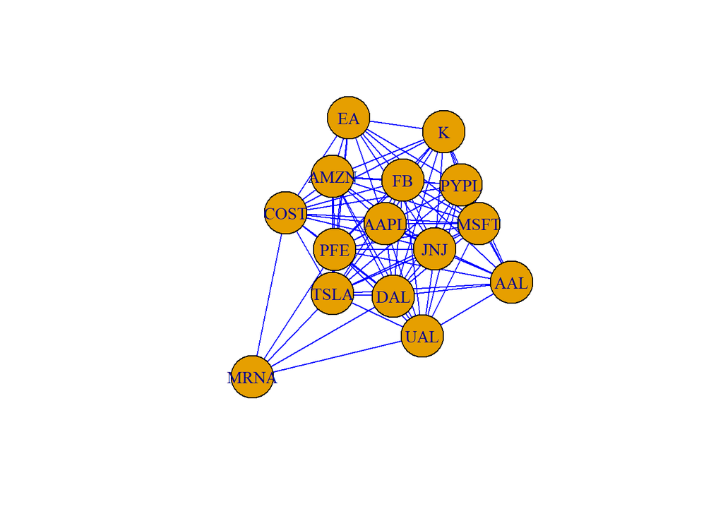

```r
# Load the package quietly
suppressWarnings( suppressMessages( require(igraph, quietly = TRUE) ) )

# Create the undirected graph G
G <- make_empty_graph(n = p, directed = FALSE) %>%
  add_edges(stock_pairs) %>%                        # Add edges
  set_edge_attr("color", value = "blue") %>%        # Set color for the edges
  set_vertex_attr("label", value = stocks) %>%      # Set the stocks as labels
  set_vertex_attr("size", value = 33)               # Set the size of the vertexes
plot(G)
```

```r
# Evaluate the degree centrality of each node
deg <- degree(G, v = V(G), mode = c("all"))
names(deg) <- stocks; sort(deg)
```

```
## MRNA  AAL   EA    K  UAL AMZN COST AAPL  DAL   FB  JNJ MSFT PYPL TSLA  PFE
##    5   10   10   11   11   12   12   13   13   13   13   13   13   13   14
```

Looking at the graph we can see how much each stock is correlated with the others of the portfolio.

With the help of the *degree centrality* values (the number of edges of each node), we can say that the *MRNA* (Moderna) stock is the less correlated with the other in the portfolio, because it has only 5 edges.

*PFE* (Pfizer) is the most correlated with 14 edges. It means that it is correlated with all the others stocks in the portfolio.

The average degree centrality of the graph is $11,73$. It is an high value if we consider that our graph has only 15 nodes. We can interpret these results, saying that, in this last period, there has been an high correlation between the stock trends, probably due to an hidden common cause: the *Covid-19*.

**Shapley values**

We can evaluate bootstrapped confidence interval for the Shapley value of each stock in our portfolio. We chose the pivotal confidence interval because we can’t do many assumptions on the symmetry or on the normality of the estimator distribution.

The formula to evaluate these values is the following:

$$\psi(j)^{G} = \mathbb{E}(X_{j}) - w \cdot \sum_{r=1}^{p} \mathbb{Cov}(X_{j}, X_{r})$$

We setted the weight $w=2$.

```r
# Set the weight
w <- 2

# Shapley value function
shapley <- function(stock, i, w) mean(stock) - w*sum(cov(X)[,i])

# Bootstrap
B <- 1000
# Matrix for the bootstrapped shapley values of each stock
shapley.boot <- matrix(NA, nrow=B, ncol=p)
# Loop
for(i in 1:B){
  idx <- sample(1:length(X[,1]), length(X[,1]), replace=TRUE)
  for(j in 1:p){
    stock.boot <- X[,j][idx]
    shapley.boot[i, j] <- shapley(stock.boot, j, w)
  }
}

# Pivotal confidence intervals

# Set alpha 0.05
alpha <- 0.05

# Set the functions to evaluate the quantile of the bootstrapped values
t1 <- function(x) quantile(x, alpha/2)
t2 <- function(x) quantile(x, 1-alpha/2)

# Initialize the matrix that we will use to visualize the 16 confidence intervals
conf.int <- matrix(NA, nrow=p, ncol=2)

# Loop
for(i in 1:p){
  conf.int[i, 1] <- round(2*mean(X[,i]) - t2(shapley.boot[, i]), 3)
  conf.int[i, 2] <- round(2*mean(X[,i]) - t1(shapley.boot[, i]), 3)
}

# Set row and col names for the matrix
rownames(conf.int) <- stocks; colnames(conf.int) <- c('lower', 'upper')

# Visualize the matrix
conf.int
```

```
##      lower upper
## AAL  0.011 0.019
## AAPL 0.009 0.013
## AMZN 0.005 0.009
## COST 0.004 0.007
## DAL  0.010 0.017
## EA   0.003 0.007
## FB   0.007 0.011
## JNJ  0.003 0.006
## K    0.001 0.004
## MRNA 0.007 0.018
## MSFT 0.008 0.012
## PFE  0.004 0.007
## PYPL 0.008 0.013
## TSLA 0.015 0.023
## UAL  0.012 0.020
```

From these confidence intervals we can see that the stocks with the highest Shapley value are *TSLA* (Tesla), *UAL* (United Airlines) and *AAL* (American Airlines Group). It means that they have an higher contribution to the total utility of our portfolio than the others.

*K* (Kellogg’s), *JNJ* (Johnson & Johnson) and *EA* (Electronic Arts) have the lowest Shapley values, so, they have a low contribution to the total utility of the portfolio.